# SpeakHalf

## "We have two ears and one mouth so we should listen more than we say."

### Zeno, Epictetus?, Socartes?, Ancient wise man.

If everyone spoke for half as long as they've been listening would all conversations have to end? How long can you keep a conversation going? How does it vary with the number of people in the conversation?

For two people, the answer is pretty obvious the first person speaks for 1 time unit, the second speaks for half of that, now the first person can only speak a quarter time unit. The conversation converges geometrically

$$1,\frac{1}{2},\frac{1}{2^2},\frac{1}{2^2},\frac{1}{2^3}$$

with the total conversation lasting two time units.

```python
import numpy as np
from matplotlib import pyplot as plt
```

```
1.9999999999999982
```

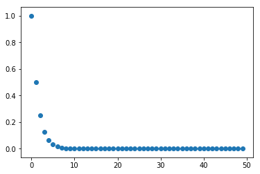

```python
x=[(1/2)**i for i in range(50)]
print(sum(x))
t=range(50)
plt.scatter(t,x)
```

So we see that a conversation between two people would end quite clearly with the total time spoken being 2.

Now if we have three people then the first two terms are the same, however the third person has been listening for one plus a half time unit thus they can speak for half of that sum. This is just a modidied fibonacci sequence where instead of the next term being the sum it is half the sum.

```python
def fibi3(n):
    a, b = 1, 1/2
    for i in range(n):
        a, b = b, (a + b)/2
    return a
```

Now we have an interesting result this sequence actually converges so that after a few rounds of talking everyone starts to speak for the same amount of time! The conversation then goes on forever, with every member contributing equally.

```
33.55555555555555
```

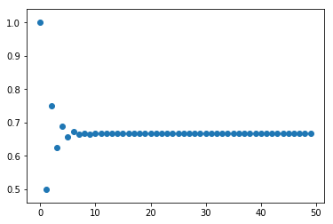

```python
x=[fibi3(n) for n in range(50)]
print(sum(x))
t=range(50)
plt.scatter(t,x)
```

What happens if we have four people?

```python
def fibi4(n):
    a,b,c=1,1/2,(1+1/2)/2

    for i in range(n):
        a,b,c=b,c,(a+b+c)/2
    return a
```

```
83730.73338109806
```

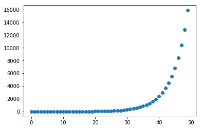

```python
x=[fibi4(n) for n in range(50)]
print(sum(x))
t1=range(50)
plt.scatter(t1,x)
```

This sequence increases monotonically so each person speaks longer then the last. Why does they happen?

We can create a sequence that represents the amount of time the nth person would speak if they were listening in on the conversation.

$$1, \frac{1}{2}, \frac{1}{2}(1+\frac{1}{2}), \frac{1}{2}(1+\frac{1}{2}+\frac{1}{2}(1+\frac{1}{2})$$

Grouping all of the $\frac{3}{2}$ terms we find that the sequence can be rewritten.

$$1,\frac{1}{2},\frac{3}{4},\frac{9}{8} = 1 , \frac{3^0}{2^1} , \frac{3^1}{2^2} , \frac{3^2}{2^3}$$

As you can see the fourth person is able to speak for a longer time than the first so that the conversation length of time that the next person can speak becomes even larger, which why see the last plot blow up so rapidly. Can we create a function to generate $n$ points from $k$ people having a conversation? Below is a seqence, which describes how long the first $k$ people talk.

```python
k=5
time_for_nth=[((3/2)**i)/3 for i in range(10)]
time_for_nth[0]=1
time_for_nth
```

```
[1,
 0.5,
 0.75,
 1.125,
 1.6875,
 2.53125,
 3.796875,
 5.6953125,
 8.54296875,
 12.814453125]
```

```python
def func(n,k):
    seq=[((3/2)**i)/3 for i in range(k)]
    seq[0]=1

    for i in range(n):
        seq[0:k]=seq[1:k] #This shifts the values toward the first variable
        seq.append(sum(seq)/2)
    return seq[0]
```

```
83730.73338109806
```

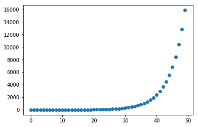

```python
values=[func(n,4) for n in range(50)]
print(sum(values))
x=range(50)
plt.scatter(x,values)
plt.show()
```

$$1, r , r(1+r) , r(1+r+r(1+r)),.,., $$ $$1, r, r(1+r), r(1+r)^2,.,.,. $$

```python
def func(n,k,r):
    seq=[r*(1+r)**i for i in range(k-1)]
    seq.insert(0,1)

    for i in range(n):
        seq[0:k-1]=seq[1:k-1] #This shifts the values toward the first variable
        seq.append(sum(seq)*r)
    return seq[0]
```

```
14.761904780325606
```

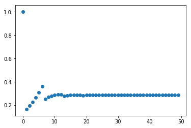

```python
#This choice of r always gives a convergent sequence.
k=7
values=[func(n,k,1/(k-1)) for n in range(50)]
print(sum(values))
x=range(50)
plt.scatter(x,values)
plt.show()
```

What are the condition for convergence of these conversations? Well a guess and check method shows that if you have k people then everyone shold speak at a rate of $\frac{1}{k-1}$ below is a plot of the limit of these sequences versus the size of the group.

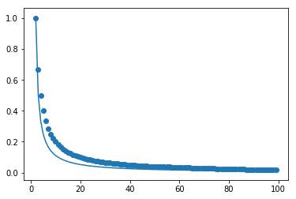

```python
k_max=100
limits=[func(10**2,i,1/(i-1)) for i in np.arange(2,k_max)]
x=np.arange(2,k_max)
plt.scatter(x , limits)
plt.plot(x,1/(x-1))
plt.show()
```